# A Quantitative Approach to Tactical Asset Allocation in South Africa

#### Importing the data into R

Each asset’s class price series has been saved as a CSV. The packages used for performance analysis and backtesting require the data to be xts objects which are created by the following code.

```r
#remove past data
rm(list = ls(envir = globalenv()),envir = globalenv()) #clear Vars from global enviroment
#Load required packages
library(PerformanceAnalytics)
library(quantstrat)
#Set Symbols
symbols <- c("TBILLS","JALSH","MSCIWORLD","SA10YR","GSCI","JASPY","SACPI")
#Import saved pricing data csv files as xts
getSymbols(symbols,
           src = "csv",
           dir="../Data/CSV files/SA Long Term/",
           col.names=c("Close"))
```

```
[1] "TBILLS"    "JALSH"     "MSCIWORLD" "SA10YR"    "GSCI"      "JASPY"     "SACPI"
```

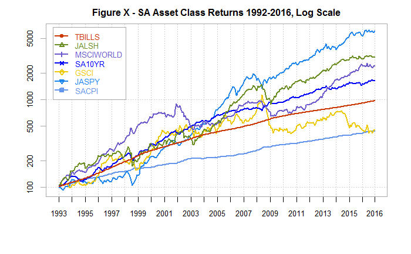

```r
#create an object with all assets to calculate returns
AllAssets <- cbind.xts(Cl(TBILLS),
                       Cl(JALSH),
                       Cl(MSCIWORLD),
                       Cl(SA10YR),
                       Cl(GSCI),
                       Cl(JASPY),
                       Cl(SACPI))
#subset to required period
SubsetPeriod <- "1992-12-31::2016-12-31"
AllAssets <- AllAssets[SubsetPeriod]
colnames(AllAssets) <- symbols
#calculate returns and cum returns
AllAssets.ret <- Return.calculate(AllAssets)[-1,]
AllAssets.cumret <- 100*cumprod(1+ ROC(AllAssets, type = "discrete")[-1,])
#chart
chart.TimeSeries(AllAssets.cumret[SubsetPeriod],
 main = paste("Figure X - SA Asset Class Returns ",substr(SubsetPeriod,1,4),"-",substr(SubsetPeriod,13,16),", Log Scale",sep = ""),
 ylab = "",
 ylog = TRUE,
 #ylim = c(100,200000),
 date.format = "%Y",
 major.ticks = "years",
 legend.loc = "topleft",
 colorset = c("orangered3","olivedrab","slateblue","blue","gold2","dodgerblue2","cornflowerblue"),
 minor.ticks =FALSE)
```

#### Analysing asset class returns, max drawdowns and other performance statistics

```r
#subset to required dates
SubsetPeriod <- "1992-12-31::2016-12-31"
#Create xts for Returns
Returns <- AllAssets.ret[SubsetPeriod]
#calculate statistics and store as "stats"
stats <- rbind(100*Return.annualized(Returns,scale = 12),
               100*StdDev.annualized(Returns,scale = 12),
               SharpeRatio.annualized(Returns,Rf = AllAssets.ret$TBILLS),
               100*maxDrawdown(Returns,scale = 12,invert = FALSE),
               100*c(Return.annualized(Returns$SACPI,scale = 12)))
#rename table rows/column names and format
colnames(stats) <- symbols
rownames(stats) <- c("Return","Volatility",paste("Sharpe (",round(stats[1,"TBILLS"],2),"%)", sep = ""),"MaxDD","Inflation CAGR")
stats <- round(stats[,-7],2)
stats
```

```
               TBILLS  JALSH MSCIWORLD SA10YR   GSCI  JASPY
Return           9.93  15.29     14.18  12.41   6.51  18.64
Volatility       1.00  18.24     16.17   8.00  22.66  15.67
Sharpe (9.93%)   0.00   0.27      0.24   0.28  -0.14   0.51
MaxDD            0.00 -40.44    -49.90 -18.63 -64.08 -31.87
Inflation CAGR   6.33   6.33      6.33   6.33   6.33   6.33
```

```r
#copies stats to clipboad for pasting into word/excel
write.table(stats, "clipboard", sep="\t", col.names=NA)
```

#### Managing Risk

Lets chart each asset with its 10 month simple moving average

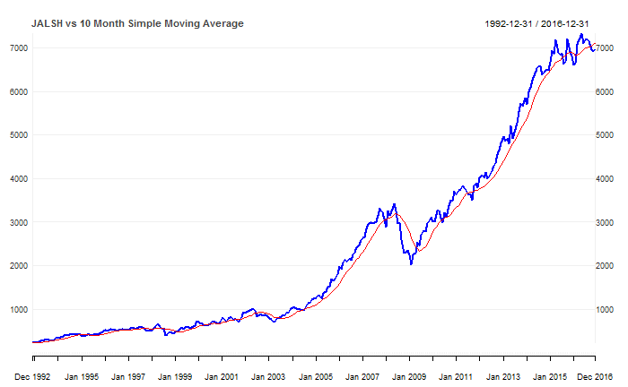

```r
myChart_Theme <- chart_theme() #Create a chart_theme
myChart_Theme$col$line.col <- "blue"
SMAperiod <- 10
chart_Series(Cl(JALSH),
  name = paste("JALSH vs 10 Month Simple Moving Average",sep = ""),
  theme=myChart_Theme,
  type = "line",
  subset = SubsetPeriod,
  TA = 'add_SMA(n=SMAperiod, on=1, col="red")'
  )
```

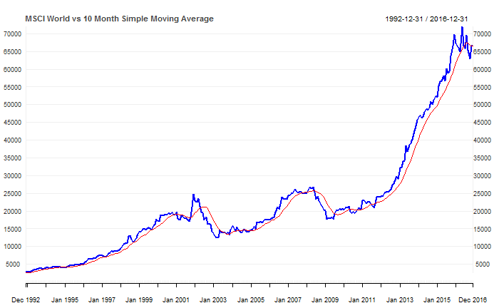

```r
chart_Series(Cl(MSCIWORLD),
  name = paste("MSCI World vs 10 Month Simple Moving Average",sep = ""),
  theme=myChart_Theme,
  type = "line",
  subset = SubsetPeriod,
  TA = 'add_SMA(n=SMAperiod, on=1, col="red")'
  )
```

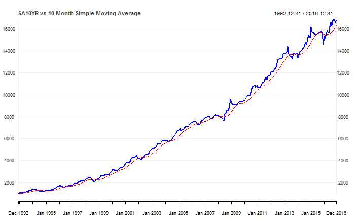

```r
chart_Series(Cl(SA10YR),
  name = paste("SA10YR vs 10 Month Simple Moving Average",sep = ""),
  theme=myChart_Theme,
  type = "line",
  subset = SubsetPeriod,
  TA = 'add_SMA(n=SMAperiod, on=1, col="red")'
  )
```

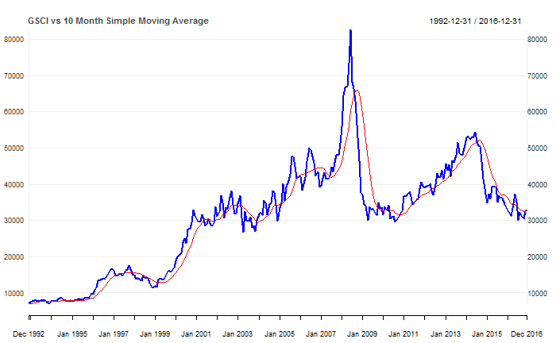

```r
chart_Series(Cl(GSCI),
  name = paste("GSCI vs 10 Month Simple Moving Average",sep = ""),
  theme=myChart_Theme,
  type = "line",
  subset = SubsetPeriod,
  TA = 'add_SMA(n=SMAperiod, on=1, col="red")'
  )
```

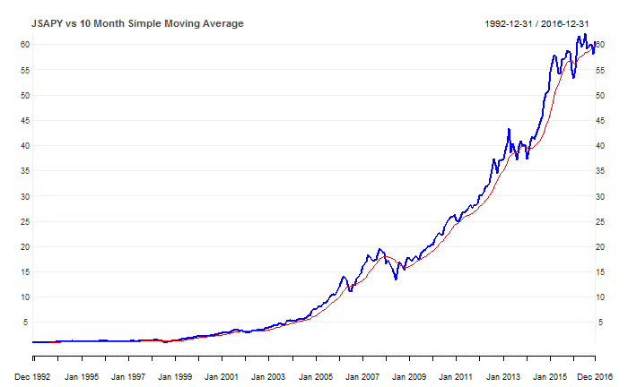

```r
chart_Series(Cl(JASPY),
   name = paste("JSAPY vs 10 Month Simple Moving Average",sep = ""),
   theme=myChart_Theme,
   type = "line",
   subset = SubsetPeriod,
   TA = 'add_SMA(n=SMAperiod, on=1, col="red")'
   )
```

```r
#change to other chart so can make it log?
```

#### Calculating returns

```r
#Import saved pricing data csv files as xts
getSymbols("TBILLYIELDS",
           src = "csv",
           dir="../Data/CSV files/SA Long Term/",
           col.names=c("Close"))
```

```
[1] "TBILLYIELDS"
```

```r
TBILLYIELDS <- TBILLYIELDS[SubsetPeriod]
#load an additional library
library(dplyr)
#Create new all assets
AllAssets <- cbind.xts(Cl(JALSH),
                       Cl(MSCIWORLD),
                       Cl(SA10YR),
                       Cl(GSCI),
                       Cl(JASPY),
                       Cl(TBILLYIELDS))
AllAssets <- AllAssets[SubsetPeriod]
#create dataframe - tidyverse not compatible with xts?
AllAssets.df <- data.frame(date=index(AllAssets), coredata(AllAssets)) #, row.names = index(AllAssets))
#mutate new columns
AllAssets.df  <- mutate(AllAssets.df,
  "JALSH.SMA" =  rollmean(JALSH.Close,10,fill = 0,align = "right"),
  "MSCIWORLD.SMA" =  rollmean(MSCIWORLD.Close,10,fill = 0,align = "right"),
  "SA10YR.SMA" =  rollmean(SA10YR.Close,10,fill = 0,align = "right"),
  "GSCI.SMA" =  rollmean(GSCI.Close,10,fill = 0,align = "right"),
  "JASPY.SMA" =  rollmean(JASPY.Close,10,fill = 0,align = "right"),
  "JALSH.ret" =  c(0,diff(JALSH.Close)/lag(JALSH.Close)[-1]),
  "MSCIWORLD.ret" =  c(0,diff(MSCIWORLD.Close)/lag(MSCIWORLD.Close)[-1]),
  "SA10YR.ret" =  c(0,diff(SA10YR.Close)/lag(SA10YR.Close)[-1]),
  "GSCI.ret" =  c(0,diff(GSCI.Close)/lag(GSCI.Close)[-1]),
  "JASPY.ret" =  c(0,diff(JASPY.Close)/lag(JASPY.Close)[-1]),
  "RF.ret" =  lag((TBILLYIELDS/100)/12),
  "JALSH.signal" =  lag(ifelse(JALSH.Close>=JALSH.SMA,1,0)),
  "MSCIWORLD.signal" =  lag(ifelse(MSCIWORLD.Close>=MSCIWORLD.SMA,1,0)),
  "SA10YR.signal" =  lag(ifelse(SA10YR.Close>=SA10YR.SMA,1,0)),
  "GSCI.signal" =  lag(ifelse(GSCI.Close>=GSCI.SMA,1,0)),
  "JASPY.signal" = lag(ifelse(JASPY.Close>=JASPY.SMA,1,0)),
  "JALSH.timingret" = ifelse(JALSH.signal == 1,JALSH.ret,RF.ret),
  "MSCIWORLD.timingret" = ifelse(MSCIWORLD.signal == 1,MSCIWORLD.ret,RF.ret),
  "SA10YR.timingret" = ifelse(SA10YR.signal == 1,SA10YR.ret,RF.ret),
  "GSCI.timingret" = ifelse(GSCI.signal == 1,GSCI.ret,RF.ret),
  "JASPY.timingret" = ifelse(JASPY.signal == 1,JASPY.ret,RF.ret),
  "GTAA.ret" = (JALSH.timingret + MSCIWORLD.timingret + SA10YR.timingret + GSCI.timingret + JASPY.timingret)/5,
  "BUYANDHOLD.ret" = (JALSH.ret + MSCIWORLD.ret + SA10YR.ret + GSCI.ret + JASPY.ret)/5
)
rownames(AllAssets.df) <- index(AllAssets)
#Create xts of calculations to analyse performance
AllAssets.xts <- xts(AllAssets.df[,-1], order.by = AllAssets.df$date)
#detach the packagae dplyr as it isn't compatible with other packages?
detach(package:dplyr)
```

#### Individual Asset class charts buy and hold vs timing

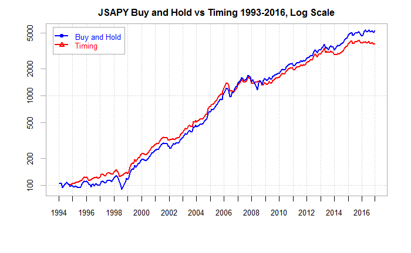

```r
SubsetPeriod <- "1993-12-31::2016-12-31"
Rf.ret <- Return.calculate(TBILLYIELDS)[-1,]
Rf.ret <- Rf.ret[SubsetPeriod]
Returns <- cbind.xts(AllAssets.xts$JASPY.ret, AllAssets.xts$JASPY.timingret)[SubsetPeriod]
CumReturns <- 100*cumprod(1+Returns[-1,])
colnames(CumReturns) <- c("Buy and Hold","Timing")
colnames(Returns) <- c("Buy and Hold","Timing")
#how do i add earlier row and make it 100
chart.TimeSeries(CumReturns,
  main = paste("JSAPY Buy and Hold vs Timing ",substr(SubsetPeriod,1,4),"-",substr(SubsetPeriod,13,16),", Log Scale",sep = ""),
  date.format = "%Y",
  colorset = c(4,2),
  ylab = "",
  ylog = TRUE,
  #ylim = c(50,1000),
  legend.loc = "topleft",
  major.ticks = "years",
  minor.ticks = FALSE)
```

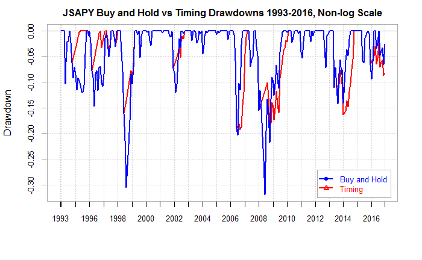

```r
chart.Drawdown(Returns,
  main = paste("JSAPY Buy and Hold vs Timing Drawdowns ",substr(SubsetPeriod,1,4),"-",substr(SubsetPeriod,13,16),", Non-log Scale",sep = ""),
  date.format = "%Y",
  colorset = c(4,2),
  ylab = "Drawdown",
  legend.loc = "bottomright",
  major.ticks = "years",
  minor.ticks = FALSE)
```

```r
stats <- rbind(Return.annualized(Returns,scale = 12)*100,
               StdDev.annualized(Returns,scale = 12)*100,
               SharpeRatio.annualized(Returns,Rf = Rf.ret$TBILLYIELDS.Close),
               maxDrawdown(Returns,scale = 12,invert = FALSE)*100,
               c(nrow(subset(Returns, Returns$JALSH.ret >= 0))/nrow(Returns),nrow(subset(Returns, Returns$JALSH.timingret >= 0))/nrow(Returns))*100)
colnames(stats) <- c("Buy and Hold","Timing")
rownames(stats) <- c("Return","Volatility","Sharpe","MaxDD","% Positive Months")
round(stats,2)
```

```
                  Buy and Hold Timing
Return                   19.40  17.71
Volatility               15.85  13.26
Sharpe                    1.15   1.26
MaxDD                   -31.87 -19.25
% Positive Months         0.00   0.00
```

```r
write.table(round(stats,4), "clipboard", sep="\t", col.names=NA)
```

#### GTAA Performance Charts

[figure not shown]

need proper yield curve! how does this compare to USA in same period?

```r
Rf.ret <- Return.calculate(TBILLS)[-1,]
Rf.ret <- Rf.ret[SubsetPeriod]
Returns <- cbind.xts(AllAssets.xts$BUYANDHOLD.ret,AllAssets.xts$GTAA.ret)[SubsetPeriod]
stats <- rbind(100*Return.annualized(Returns,scale = 12),
               100*StdDev.annualized(Returns,scale = 12),
               SharpeRatio.annualized(Returns,Rf = Rf.ret$TBILLS.Close),
               #SortinoRatio(Returns, MAR = 0),
               100*maxDrawdown(Returns,invert = FALSE),
               100*c(Return.annualized(Return.calculate(Cl(SACPI))[SubsetPeriod],scale = 12))
               )
colnames(stats) <- c("Buy & Hold","GTAA")
rownames(stats) <- c("Return",
                     "Volatility",
                     "Sharpe",
                     #"Sortino",
                     "MaxDD",
                     "Inflation CAGR")
round(stats,2)
```

```
               Buy & Hold  GTAA
Return              14.28 14.30
Volatility           9.44  7.04
Sharpe               0.43  0.58
MaxDD              -22.19 -9.59
Inflation CAGR       6.19  6.19
```

```r
write.table(round(stats,4), "clipboard", sep="\t", col.names=NA)
#look to add skewness/ kurtosis
```

so better sharpe? [confirm calc method/fix interest rate… should i calc manually?] and less maxdd whats kurtosis, information ratio, skew. ask what metrics rad, mb and emyln use… run on longer dater in asset allocation ratios last 12 months, 3 years, etc returns rolling returns

to do:

- how to calculate dailyreturns with NA
- check returns make sense - effect of zar?
- compare to US / JPY
- Daily drawdowns
- monthly returns table
- Relative performance / rolling perofrmance / alpha
- 10 worst periods / 10 best periods
- do different averages improve SA - check robustness of averages….

#### Calculating returns of WMAF / SAMAF

```r
#Import saved pricing data csv files as xts
getSymbols("TBILLYIELDS",
           src = "csv",
           dir="../Data/CSV files/SA Long Term/",
           col.names=c("Close"))
TBILLYIELDS <- TBILLYIELDS[SubsetPeriod]

#load an additional library
library(dplyr)

#Create new all assets
AllAssets <- cbind.xts(Cl(JALSH),
                       Cl(MSCIWORLD),
                       Cl(SA10YR),
                       Cl(GSCI),
                       Cl(JASPY),
                       Cl(TBILLYIELDS))

SubsetPeriod <- "1992-12-31::2016-12-31"

AllAssets <- AllAssets[SubsetPeriod]

#create dataframe - tidyverse not compatible with xts?
AllAssets.df <- data.frame(date=index(AllAssets), coredata(AllAssets)) #, row.names = index(AllAssets))

#mutate new columns
AllAssets.df  <- mutate(AllAssets.df,
  "JALSH.SMA" =  rollmean(JALSH.Close,10,fill = 0,align = "right"),
  "MSCIWORLD.SMA" =  rollmean(MSCIWORLD.Close,10,fill = 0,align = "right"),
  "SA10YR.SMA" =  rollmean(SA10YR.Close,10,fill = 0,align = "right"),
  "GSCI.SMA" =  rollmean(GSCI.Close,10,fill = 0,align = "right"),
  "JASPY.SMA" =  rollmean(JASPY.Close,10,fill = 0,align = "right"),
  "JALSH.ret" =  c(0,diff(JALSH.Close)/lag(JALSH.Close)[-1]),
  "MSCIWORLD.ret" =  c(0,diff(MSCIWORLD.Close)/lag(MSCIWORLD.Close)[-1]),
  "SA10YR.ret" =  c(0,diff(SA10YR.Close)/lag(SA10YR.Close)[-1]),
  "GSCI.ret" =  c(0,diff(GSCI.Close)/lag(GSCI.Close)[-1]),
  "JASPY.ret" =  c(0,diff(JASPY.Close)/lag(JASPY.Close)[-1]),
  "RF.ret" =  lag((TBILLYIELDS/100)/12),
  "JALSH.signal" =  lag(ifelse(JALSH.Close>=JALSH.SMA,1,0)),
  "MSCIWORLD.signal" =  lag(ifelse(MSCIWORLD.Close>=MSCIWORLD.SMA,1,0)),
  "SA10YR.signal" =  lag(ifelse(SA10YR.Close>=SA10YR.SMA,1,0)),
  "GSCI.signal" =  lag(ifelse(GSCI.Close>=GSCI.SMA,1,0)),
  "JASPY.signal" = lag(ifelse(JASPY.Close>=JASPY.SMA,1,0)),
  "JALSH.timingret" = ifelse(JALSH.signal == 1,JALSH.ret,RF.ret),
  "MSCIWORLD.timingret" = ifelse(MSCIWORLD.signal == 1,MSCIWORLD.ret,RF.ret),
  "SA10YR.timingret" = ifelse(SA10YR.signal == 1,SA10YR.ret,RF.ret),
  "GSCI.timingret" = ifelse(GSCI.signal == 1,GSCI.ret,RF.ret),
  "JASPY.timingret" = ifelse(JASPY.signal == 1,JASPY.ret,RF.ret),
  "GTAA.ret" = (JALSH.timingret + MSCIWORLD.timingret + SA10YR.timingret + GSCI.timingret + JASPY.timingret)/5,
  "BUYANDHOLD.ret" = (JALSH.ret + MSCIWORLD.ret + SA10YR.ret + GSCI.ret + JASPY.ret)/5,
  "WMAF.GTAA.ret" = (JALSH.timingret * 0.225) + (MSCIWORLD.timingret * 0.225) + (SA10YR.timingret * 0.225) + (GSCI.timingret * 0.1) + (JASPY.timingret * 0.225),
  "WMAF.BUYANDHOLD.ret" = (JALSH.ret * 0.225 +  MSCIWORLD.ret * 0.225 + SA10YR.ret * 0.225 + GSCI.ret * 0.1 + JASPY.ret * 0.225),
  "SAMAF.GTAA.ret" = (JALSH.timingret * 0.25) + (MSCIWORLD.timingret * 0.15) + (SA10YR.timingret * 0.25) + (GSCI.timingret * 0.1) + (JASPY.timingret * 0.25),
  "SAMAF.BUYANDHOLD.ret" = (JALSH.ret * 0.25 + MSCIWORLD.ret * 0.15 + SA10YR.ret * 0.25 + GSCI.ret * 0.1 + JASPY.ret * 0.25)
)

rownames(AllAssets.df) <- index(AllAssets)

#Create xts of calculations to analyse performance
AllAssets.xts <- xts(AllAssets.df[,-1], order.by = AllAssets.df$date)

#detach the packagae dplyr as it isn't compatible with other packages?
detach(package:dplyr)
```

#### GTAA Performance Charts

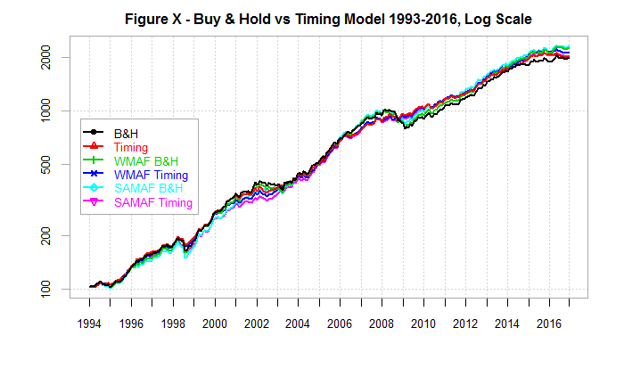

```r
SubsetPeriod <- "1993-12-31::2016-12-31"
Returns <- cbind.xts(AllAssets.xts$BUYANDHOLD.ret,AllAssets.xts$GTAA.ret,AllAssets.xts$WMAF.BUYANDHOLD.ret,AllAssets.xts$WMAF.GTAA.ret,AllAssets.xts$SAMAF.BUYANDHOLD.ret,AllAssets.xts$SAMAF.GTAA.ret)[SubsetPeriod]
CumReturns <- 100*cumprod(1+Returns[-1,])
colnames(CumReturns) <- c("B&H","Timing","WMAF B&H","WMAF Timing","SAMAF B&H","SAMAF Timing")
chart.TimeSeries(CumReturns["1973-01-31::2016-12-31"],
  main = paste("Figure X - Buy & Hold vs Timing Model ",substr(SubsetPeriod,1,4),"-",substr(SubsetPeriod,13,16),", Log Scale",sep = ""),
  date.format = "%Y",
  #colorset = c(4,2),
  ylab = "",
  ylog = TRUE,
  #ylim = c(100,500),
  legend.loc = "left",
  major.ticks = "years",
  minor.ticks = FALSE)
```

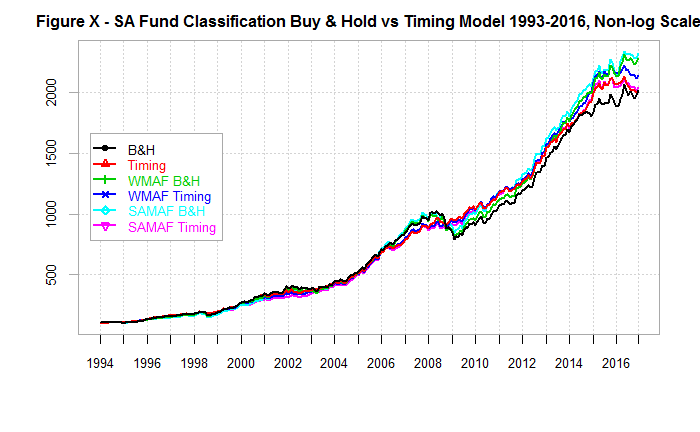

```r
chart.TimeSeries(CumReturns["1973-01-31::2016-12-31"],
  main = paste("Figure X - SA Fund Classification Buy & Hold vs Timing Model ",substr(SubsetPeriod,1,4),"-",substr(SubsetPeriod,13,16),", Non-log Scale",sep = ""),
  date.format = "%Y",
  #colorset = c(4,2),
  ylab = "",
  ylog = FALSE,
  #ylim = c(100,500),
  legend.loc = "left",
  major.ticks = "years",
  minor.ticks = FALSE)
```

```r
round(stats,2)
```

[output not shown]